# Tugas Praktikum 6

Tri Ananda Marpaung | M0401241098

```r
library(ggplot2)
library(tsibble)
library(MASS)
library(forecast)
library(TSA)
library(TTR)
library(aTSA)
library(graphics)
```

```r
library(readxl)
PM25 <- read_excel("C:/Users/Dewi Lestari Natalia/Downloads/PM25_Anggota_5.xlsx", skip = 2)
# Lihat struktur data
head(PM25)
```

```
## # A tibble: 6 × 3
##       t Tanggal    `PM2.5 (ug/m3)`
##   <dbl> <chr>                <dbl>
## 1     1 2025-09-16           103.
## 2     2 2025-09-17            83.0
## 3     3 2025-09-18            83.1
## 4     4 2025-09-19            92.9
## 5     5 2025-09-20            65.7
## 6     6 2025-09-21            96.5
```

```r
str(PM25)
```

```
## tibble [156 × 3] (S3: tbl_df/tbl/data.frame)
##  $ t            : num [1:156] 1 2 3 4 5 6 7 8 9 10 ...
##  $ Tanggal      : chr [1:156] "2025-09-16" "2025-09-17" "2025-09-18" "2025-09-19" ...
##  $ PM2.5 (ug/m3): num [1:156] 102.8 83 83.1 92.9 65.7 ...
```

```r
str(PM25)
```

```
## tibble [156 × 3] (S3: tbl_df/tbl/data.frame)
##  $ t            : num [1:156] 1 2 3 4 5 6 7 8 9 10 ...
##  $ Tanggal      : chr [1:156] "2025-09-16" "2025-09-17" "2025-09-18" "2025-09-19" ...
##  $ PM2.5 (ug/m3): num [1:156] 102.8 83 83.1 92.9 65.7 ...
```

```r
PM25$Tanggal <- as.Date(PM25$Tanggal)

PM25$PM25 <- as.numeric(PM25[[3]])

# Cek data
head(PM25)
```

```
## # A tibble: 6 × 4
##       t Tanggal    `PM2.5 (ug/m3)`  PM25
##   <dbl> <date>               <dbl> <dbl>
## 1     1 2025-09-16           103.  103.
## 2     2 2025-09-17            83.0  83.0
## 3     3 2025-09-18            83.1  83.1
## 4     4 2025-09-19            92.9  92.9
## 5     5 2025-09-20            65.7  65.7
## 6     6 2025-09-21            96.5  96.5
```

```r
summary(PM25$PM25)
```

```
##    Min. 1st Qu.  Median    Mean 3rd Qu.    Max.
##   18.08   40.50   65.24   64.94   86.08  131.70
```

# 1. Ekplorasi Data

# 1.1 Plot Data Penuh

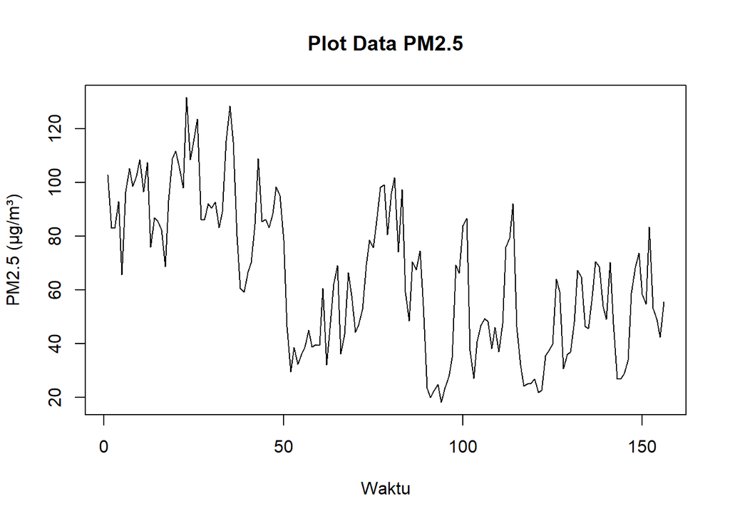

```r
PM25.ts <- ts(PM25$PM25)

plot.ts(
  PM25.ts,
  lty = 1,
  xlab = "Waktu",
  ylab = "PM2.5 (µg/m³)",
  main = "Plot Data PM2.5"
)
```

# 1.2 Plot Data Latih

```r
n <- length(PM25$PM25)

n_train <- floor(0.86 * n)

n_train
```

```
## [1] 134
```

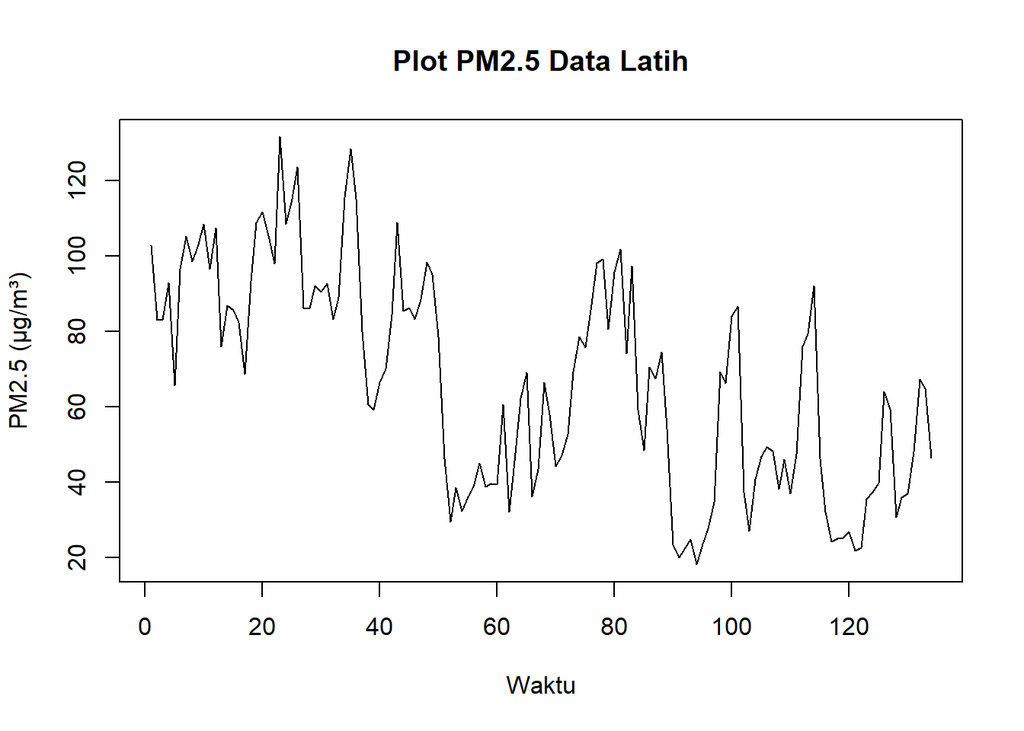

```r
PM25train <- PM25$PM25[1:n_train]

train.ts <- ts(PM25train)

plot.ts(
  train.ts,
  lty = 1,
  xlab = "Waktu",
  ylab = "PM2.5 (µg/m³)",
  main = "Plot PM2.5 Data Latih"
)
```

Berdasarkan plot data latih PM2.5, pola pergerakan data pada periode pelatihan relatif menggambarkan karakteristik deret waktu secara keseluruhan. Data menunjukkan fluktuasi dari waktu ke waktu.

# 1.3 Plot Data Uji

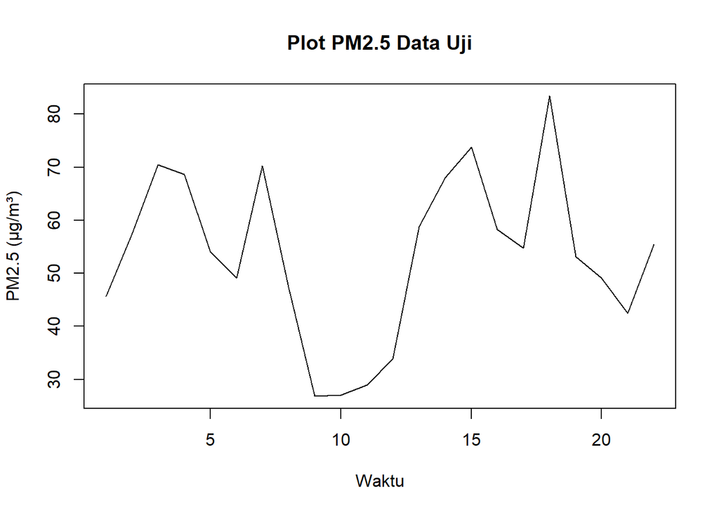

```r
PM25test <- PM25$PM25[(n_train + 1):n]

test.ts <- ts(PM25test)

plot.ts(
  test.ts,
  lty = 1,
  xlab = "Waktu",
  ylab = "PM2.5 (µg/m³)",
  main = "Plot PM2.5 Data Uji"
)
```

Berdasarkan plot data uji PM2.5, terlihat bahwa data uji tetap menunjukkan fluktuasi nilai dari waktu ke waktu.

# 2. Uji Stasioneritas Data

# 2.1 Plot ACF

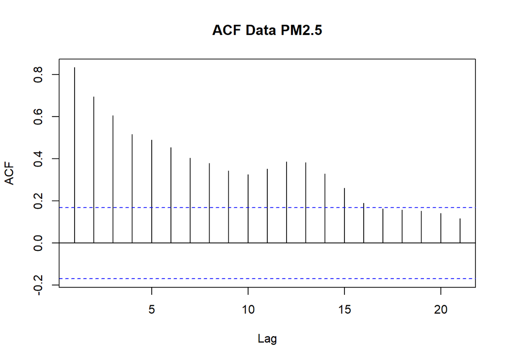

```r
acf(
  train.ts,
  main = "ACF Data PM2.5"
)
```

Plot menunjukkan Pola menurun secara perlahan(tails off slowly) mengindikasikan data tidak stasioner. # 2.2 Uji ADF

```r
tseries::adf.test(train.ts)
```

```
##
##  Augmented Dickey-Fuller Test
##
## data:  train.ts
## Dickey-Fuller = -3.5136, Lag order = 5, p-value = 0.04383
## alternative hypothesis: stationary
```

H0 : Data tidak stasioner dalam rataan H1 : Data stasioner dalam rataan

Berdasarkan uji ADF, didapat p-value sebesar 0.04383 yang lebih kecil dari taraf nyata 5% sehingga Tolak H0 dan menandakan data stasioner dalam rataan.

# 2.3 Plot Box-Cox

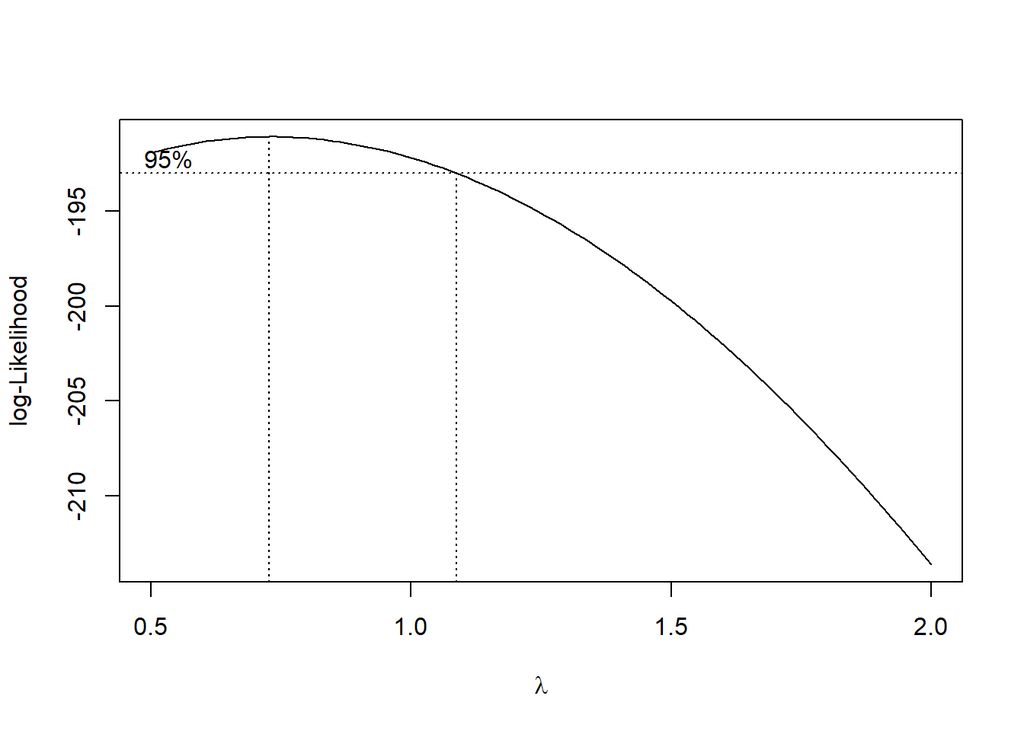

```r
index <- seq(1:length(train.ts))

bc <- boxcox(
  train.ts ~ index,
  lambda = seq(0.5, 2, by = 0.1)
)
```

```r
# Selang kepercayaan 95% untuk lambda
ci_lambda <- bc$x[bc$y > max(bc$y) - 0.5 * qchisq(0.95, df = 1)]

# Batas bawah dan batas atas
ci_lower <- min(ci_lambda)
ci_upper <- max(ci_lambda)

c(Batas_Bawah = ci_lower, Batas_Atas = ci_upper)
```

```
## Batas_Bawah  Batas_Atas
##    0.500000    1.075758
```